# A1 Loss Development Using Credibility

Brosius

April 09, 2016

## Cliff’s Summary

Least Square

- Least Square Formula
  - Know how to do them with calculator
  - Remember to adjust for exposure if needed
- Theorectical dis<sup>n</sup> formulas: Poi-Bin and NB-Bin
- Know the conclusions on LS

Method comparisons

- Pros and cons of each method
- The different $a$ and $b$ for each methods

Bayesian Credibility

- Know which method is best given the Cov and Var relationships
- Development Formula:  
  Can use the credibility formula to get the LS results
- Case load effect

Additional considerations for calculations

### Types of Exam Questions

Haven’t done TIA practice questions

**Concepts**

- 1996 - #28: Poi-bin process
- 1996 - #50: When to use LS
- 2000 - #2: Method assumptions
- 2001 - #22: Which method is better given the Cov(X,Y) and Var(X) relationships
- 2003 - #3: $a$ and $b$ for different methods
- $\star$ 2006 - #4: Cov(X,Y) and Var(X) relationships (phrased a bit differently)
- 2006 - #15 d: LS assumptions
- 2007 - #42: Method assumptions
- 2009 - #3 b: LS assumptions (LS not best given $b < 0$)
- 2014 #2: Know assumptions of methods for Dev (fitted line and residuals)

**Full Calculations**

**Simple Plug and Play**

- 1998 - #19: BF with LS
- $\star$ 2003 - #22: Dev and ELR, key is to adjust for exposure
- 2005 - #12: LS calc by $a$ and $b$
- 2006 - #5: LS calc by $a$ and $b$
- 2006 - #15 a-c: Dev, BF, and cred
- 2009 - #3 a: LS Calc
- 2012 ‐ #1 a: Dev, BF, Benktander

## Method Assumptions

| Method | Formula | Restrictions |
| --- | --- | --- |
| Least Squares | $y = a + bx$ | No Restriction |
| Chainladder | $y = bx$ | a = 0 |
| BF | $y = a + x$ | b = 1 |
| ELR | $y = a$ | b = 0 |

**Least Squares Formula**

Memorize

- $b = \dfrac{\overline{xy} - \bar{x}\bar{y}}{\overline{x^2}-\bar{x}^2} = \dfrac{\mathrm{Cov}(X,Y)}{\mathrm{Var}(X)}$
- $a = \bar{y} - b\bar{x}$

Use Calculator

**Caveat with Traditional Method**

- *Chainladder*: Difficult to select LDF when vary from year to year
- *BF*: Doesn’t work well with negative development
- **ELR***: Ignores actual experience
- Difficulty with parameter estimation when loss patterns are changing
- Variable book $\Rightarrow$ sampling error $\Rightarrow$ *b* that doesn’t reflect the true underlying characteristics

**Caveat with Least Squares**

- Good when dist<sup>n</sup> is the same across multiple years
- Bad when systemic shift year to year e.g. inflation, legal environment (Tort reform)

## LS w/ Theoretical Dist<sup>n</sup> Using Bayes

**Poisson - Binomial**  
$Y =$ (Ultimate) # of claims incurred each year $\sim Poi(\mu)$  
$X =$ # of claims reported by year end $\sim Bin(y,d)$

Unreported claims = $R(x) = \mu(1-d)$ Memorize

Simulation of Poi - Bin from paper shows that:

- LDF shows upward bias
- MSE of LDF is higher than MSE of LS

**Negative Binomial - Binomial**  
$Y =$ (Ultimate) # of claims incurred each year $\sim NB(r, p)$

- $Y =$ # of failures until $r$ success with success probability = $p$
- $\mathrm{E[Y]} = \dfrac{r(1-p)}{p}$

$X =$ # of claims reported by year end $\sim Bin(y,d)$

Unreported claims = $R(x) = \dfrac{s}{1-s}(x + r)$ Memorize

- $s = (1-d)(1-p)$

## Bayesian Credibility

Memorize

**Best linear estimator** of Y|X

$L(x) = (x - \mathrm{E[X]})\dfrac{Cov(X,Y)}{Var(X)} + \mathrm{E[Y]}$

- Y = Ultimate Losses; X = Reported Losses
- $L(x)$ = best linear estimator of Y|X = least square estimate
- Use this when we don’t know the distribution of the random variable

| Scenarios | Implications |
| --- | --- |
| $x = \mathrm{E[X]}$ | $L(X) = \mathrm{E[Y]}$ |
| $\mathrm{Cov(X,Y)} \ll \mathrm{Var(X)}$ | $L(X) \approx \mathrm{E[Y]}$; Use ELR Method; X, Y don’t vary tightly together |
| $\mathrm{Cov(X,Y)} \approx \mathrm{Var(X)}$ | $L(X) \approx x + \mathrm{E[Y - X]}$; Use BF Method |
| $\mathrm{Cov(X,Y)} \gg \mathrm{Var(X)}$ | Y is significantly influenced by X; Use Dev Method |

### Credibility Form of the Dev’ Formula

Memorize

$L(x) = Z \underbrace{\dfrac{x}{d}}_{\begin{array}{c} \text{Dev'}\\ \text{Method}\\ \end{array}} + (1-Z)\underbrace{\mathrm{E[Y]}}_{ELR}$

- $L(x) = Q(x)$ when $Q(x)$ is linear

**Method 1 for Z**

- $Z = \dfrac{VHM}{VHM + EVPV} = \dfrac{\mathrm{Var_Y(E[X|Y])}}{\mathrm{Var_Y(E[X|Y])}+\mathrm{E_Y[Var(X|Y)]}}$
  - $VHM = d^2 \sigma^2_Y$
  - $EVPV = \sigma^2_d[\sigma^2_Y + \mathrm{E[Y]}^2]$
  - Use this when underlying distribution not stable (historical not a good predictor); LS only works when the underlying dist<sup>n</sup> are stable
- $d =$ % reported
  - $d \: {\perp\!\!\!\perp} \: X$: reporting speed does not vary with the volume of claims
  - $D = \dfrac{X}{Y}$
- Results sensitive to $\mathrm{E[Y]}$ and $\mathrm{E[D]}$ but not the $\sigma$
- Based on estimates of VHM and EVPV of the dist<sup>n</sup> instead

**Method 2 for Z**

- $Z = \dfrac{b}{c}$, where $c$ is the CDF and $b$ is from the LS
  - This yield the LS results (always?)
  - Assume same $d$ for any size of $y$; Not necessarily true for large or small $y$

#### Special Case: Poi - Bin

- $L(x) = x + (1-d)\mathrm{E(Y)}$
- $Z = d$
- Same as BF
- **BF is optimal** when claim counts follow Poi - Bin

### Caseload Effect

When $D$ and $Y$ not independent still works

- e.g. $d$ larger for small $y$ since small claims are settle faster
- Or the opposite when large $y$ has as larger $d$: For a property book when large weather event happens, report quicker

Memorize

$L(x) = Z \dfrac{x - x_0}{d} + (1-Z)\mathrm{E[Y]}$

**Assumption**:  
$\mathrm{E[X|Y=y]} = dy + x_0$; $x_0$ is for the fixed salary

### Calculation Considerations

**Normalize** the losses by dividing with premium since LS assume constant distribution and also *adjust for inflation*

Calculates ATU, so needs the tail factor first and also start from the oldest period

Recursively go backwards using the previous estimates

$Z = \dfrac{b}{c}$; $c$ is the ATU

Notes:

## Conclusions

LS is the best linear estimate of $Q(x)$, the theoretical best estimate of the ultimate loss

LS produce more reasonable results when year to year fluctuations are severe

LS does not do well when the variations are due to underlying changes in the payment pattern (due to internal or external changes)

- e.g. When there is a systematic shift in the business

Subject to sampling error when estimating parameters similar to other methods

## Past Exam Questions

2000 - #41

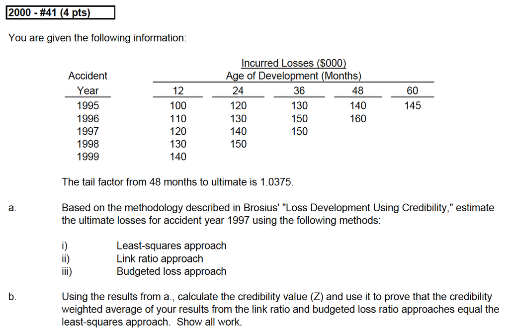

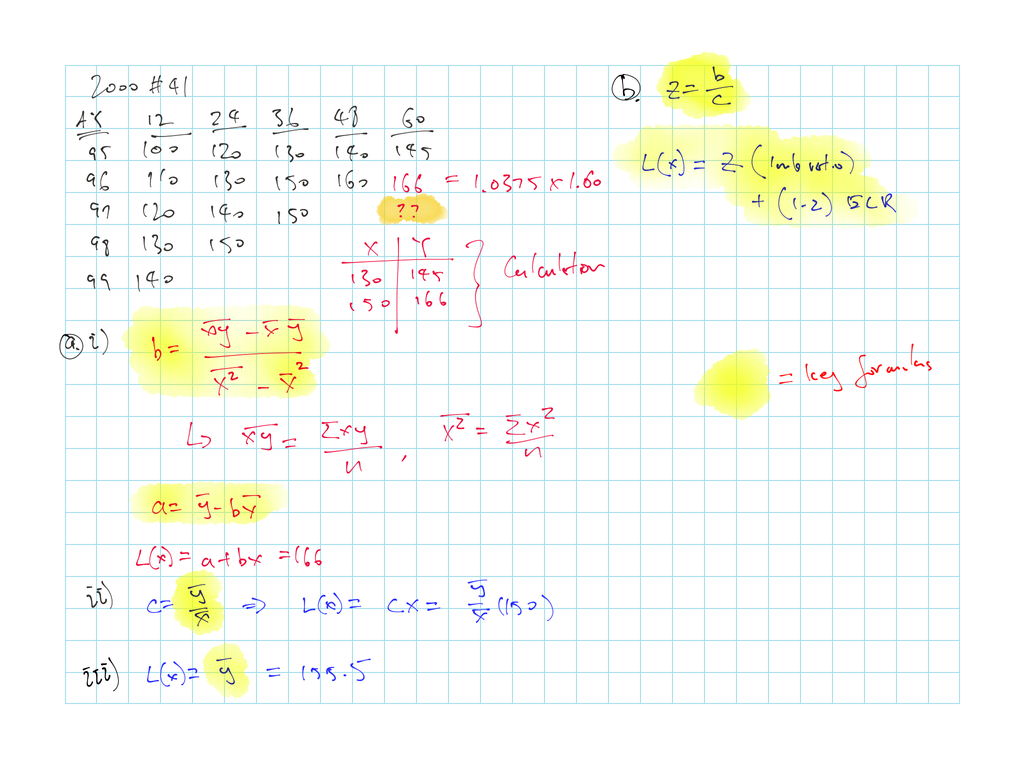

2001 - #30

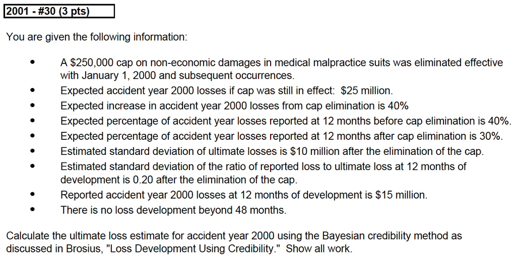

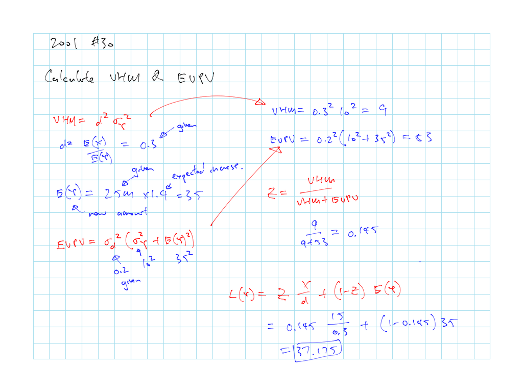